# ECE330 Exam 1 高频题型与逐题出处

这份资料统计刚下载的八份空白 Exam 1：Fall 2019、Spring 2021、Fall 2021、Spring 2022、Spring 2023、Fall 2023、Spring 2024、Fall 2024，共 32 道大题。**单相负载、平衡三相、单线圈磁路三类主干均出现于 8/8 份试卷；求自互感参数与电容补偿分别出现于 7/8。**

整理日期为 2026 年 10 月 1 日。频率是这八份历史卷的事实统计，不能据此保证本次考试会出哪些题。分类由本次整理定义，不冒充教师的官方题型划分。

**现在可直接阅读 10 道代表题的完整解答**

## 统计口径与阅读方法

- **主指标为卷次**：一类题在同一卷出现一次或多次，均记该卷 1 次。分母始终为 8。
- **题组数为辅助指标**：同卷不同 Problem 各计一次；同一 Problem 下多个小问不拆开刷高次数。
- 三类主干按 Problem 1、2、3 的综合任务统计；其余七类为跨题或嵌在主干中的专项。类别允许重叠，**不能把各类次数相加当成独立题数或占分比例**。
- RMS 换算、复数运算、点端判号等是跨题基础技能，不与综合任务混在同一排行榜重复拆分。Y/Δ 每相建模及换接归三相类；感应电压归磁路或耦合响应类。
- **仅写“忽略边缘效应”不算考查边缘效应**；只有要求计入或解释其后果才计入 J 类。题干给了 L、M 但不要求求它们，不计入 D 类。
- 为保持合理粒度，本册保留 10 类：前三类并列 8 卷，两类并列 7 卷，随后 6 卷与 5 卷；第 8 名位置有三类并列 3 卷，所以全部保留。
- 页码均为 **PDF 从封面算起的物理页码**，不是 solution 页码。原卷的小问跳号照录，例如 fa19 的 1(a,c,d,e)、2(a,b,d,e)。
- 每类先看证据，再练代表题。蓝底折叠区提供完整英文原页及原图；中文题意、方法和模型为本次整理。详细中文解答直接显示；官方答案原页放在折叠区供核对，三个自测练习的参考答案仍折叠。

## 频率排序

| 类别 | 任务 | 出现卷次 | 样本比例 | 题组数 |
| --- | --- | --- | --- | --- |
| A | 单相负载的相量 复功率与功率因数 | **8/8** | 100.0% | 8 |
| B | 平衡三相负载的线量 相量与总功率 | **8/8** | 100.0% | 8 |
| C | 单线圈磁路的磁阻 磁通 磁链与电感 | **8/8** | 100.0% | 8 |
| D | 求自感 互感及耦合线圈的等效电感 | **7/8** | 87.5% | 7 |
| E | 电容补偿及补偿前后功率因数和电流 | **7/8** | 87.5% | 9 |
| F | 耦合线圈开路电压与短路电流 | **6/8** | 75.0% | 6 |
| G | 理想变压器匝比与阻抗折算 | **5/8** | 62.5% | 5 |
| H | 馈线压降 源端功率与负载端功率 | **3/8** | 37.5% | 3 |
| I | 由磁通密度求电流与饱和上限 | **3/8** | 37.5% | 3 |
| J | 边缘效应对磁阻 电感 互感和电流的影响 | **3/8** | 37.5% | 3 |

## 八卷出现矩阵

✓ 表示该卷至少有一题达到本册该类别定义；— 表示未出现，不表示完全没有用到相关基础知识。

| 类别 | fa19 | sp21 | fa21 | sp22 | sp23 | fa23 | sp24 | fa24 |
| --- | --- | --- | --- | --- | --- | --- | --- | --- |
| A | ✓ | ✓ | ✓ | ✓ | ✓ | ✓ | ✓ | ✓ |
| B | ✓ | ✓ | ✓ | ✓ | ✓ | ✓ | ✓ | ✓ |
| C | ✓ | ✓ | ✓ | ✓ | ✓ | ✓ | ✓ | ✓ |
| D | ✓ | ✓ | ✓ | ✓ | ✓ | ✓ | ✓ | — |
| E | ✓ | — | ✓ | ✓ | ✓ | ✓ | ✓ | ✓ |
| F | ✓ | — | ✓ | ✓ | ✓ | — | ✓ | ✓ |
| G | — | ✓ | ✓ | — | ✓ | ✓ | — | ✓ |
| H | ✓ | — | ✓ | — | — | — | — | ✓ |
| I | — | — | — | ✓ | — | ✓ | ✓ | — |
| J | — | ✓ | — | ✓ | — | ✓ | — | — |

## 高频题型与代表原题

### A 单相负载的相量 复功率与功率因数

**8 份试卷出现，共 8 个题组。** 统计每卷 Problem 1 的单相负载综合题。含单负载和多负载；变压器题中顺带计算负载功率不另计为这一主干题型。

#### 出现次数的逐项证据

| 试卷 | 原题号 | PDF 页码 | 题面证据与归类理由 |
| --- | --- | --- | --- |
| Fall 2019 PDF | 1(a,c,d,e) | 2, 3 | 三种并联负载，求各支路电流、源电压、源端与负载端 PF。 |
| Spring 2021 PDF | 1(a,b) | 2 | 由电压电流波形求平均功率；再求两个并联负载的总电流与 PF。 |
| Fall 2021 PDF | 1(a–d) | 2, 3 | 10 kW、0.8 lagging 负载与馈线，求源电流、电压、复功率、PF。 |
| Spring 2022 PDF | 1(a–c) | 2, 3 | 100 W、0.6 lagging 与 1 A、0.6 leading 两负载，求支路电流和综合 PF。 |
| Spring 2023 PDF | 1(a,b) | 2 | 2 kV、100 A、150 kW 的两负载系统，求电流角度与第二负载复功率。 |
| Fall 2023 PDF | 1(a,b) | 2, 3 | 157 cos(377t+15°) V，800 W+j400 VAR 与 14∠20° Ω，求时域电流和总复功率。 |
| Spring 2024 PDF | 1(a,b) | 2 | 100∠30° V，180 W、0.6 lagging 与 1 A、0.6 leading，求两支路电流。 |
| Fall 2024 PDF | 1(a–c) | 2, 3 | 100 A、8 kW 和 (5+j2) Ω 三负载，求源功率、时域量和负载端 PF。 |

#### 代表题整理

**选题：Spring 2024，Problem 1(a,b)，PDF 第 2 页。**

电源为 100∠30° V；负载 1 消耗 180 W，PF=0.6 滞后；负载 2 电流幅值为 1 A，PF=0.6 超前。求两负载电流相量，允许直角或极坐标形式，须写单位。

**展开完整英文原题与原图**

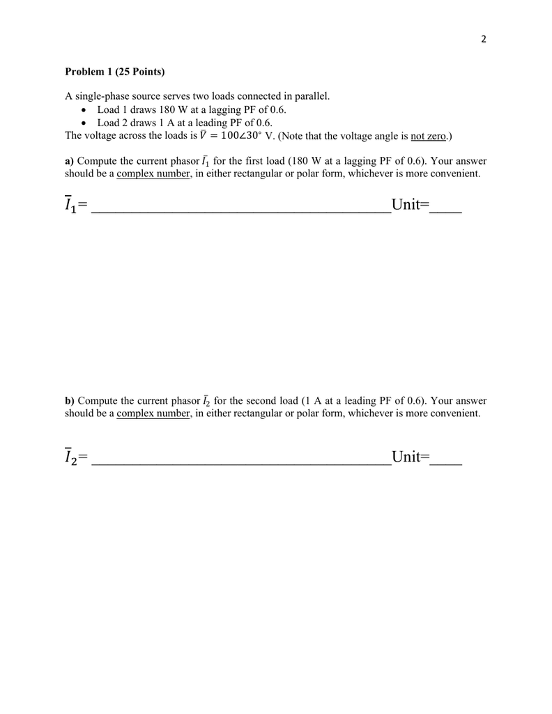

#### 建模与解题抓手

[figure not shown]

图为本次绘制的分析模型；J 为气隙局部示意。以本段条件与符号为准，具体原题拓扑和极性仍可在上方原页核对。

先把 lagging（滞后）对应为 $Q>0$，leading（超前）对应为 $Q<0$；所有相量使用 RMS（有效值）。

$$\bar S=P+jQ=\bar V\bar I^*,\qquad \bar I=\left(\frac{\bar S}{\bar V}\right)^*,\qquad \bar S_{\mathrm{tot}}=\sum_k\bar S_k.$$

共轭作用在整个 $\bar S/\bar V$ 上，角度变号。对阻抗负载直接用 $\bar I=\bar V/\bar Z$。不要把电流幅值直接相加，也不要平均各支路 PF。

### 详细解答 · 求两支路电流

**1. 确定电压参考与功率因数角**

已知电压不是零相位。两负载的功率因数角相同：

$$\bar V=100\angle30^\circ\ \mathrm{V},\qquad \varphi=\cos^{-1}(0.6)=53.130^\circ.$$

**2. 负载 1：由有功功率求电流幅值**

$$P_1=|\bar V|\,|\bar I_1|\,\mathrm{PF}_1,$$
$$|\bar I_1|=\frac{P_1}{|\bar V|\,\mathrm{PF}_1}=\frac{180}{100\times0.6}=3\ \mathrm{A}.$$

滞后表示电流比电压晚，因此电流角度减去功率因数角：

$$\theta_{I_1}=\theta_V-\varphi=30^\circ-53.130^\circ=-23.130^\circ.$$
$$\boxed{\bar I_1=3\angle(-23.130^\circ)\ \mathrm{A}=(2.759-j1.178)\ \mathrm{A}.}$$

**3. 负载 2：已知幅值，确定超前角度**

超前表示电流比电压早，所以应加上功率因数角：

$$\theta_{I_2}=\theta_V+\varphi=30^\circ+53.130^\circ=83.130^\circ.$$
$$\boxed{\bar I_2=1\angle83.130^\circ\ \mathrm{A}=(0.1196+j0.9928)\ \mathrm{A}.}$$

**4. 用复功率检查答案**

$$\bar S_1=\bar V\bar I_1^*=180+j240\ \mathrm{VA},\qquad Q_1>0,$$
$$\bar S_2=\bar V\bar I_2^*=60-j80\ \mathrm{VA},\qquad Q_2<0.$$

第一支路无功为正，符合滞后；第二支路无功为负，符合超前。**易错点：**不能把电压的 $30^\circ$ 丢掉，直接写成电流角 $-53.13^\circ$。

**核对官方答案原页（直接在本页查看）**

以下是官方 solution 的 PDF 第 2 页。打开完整官方 PDF

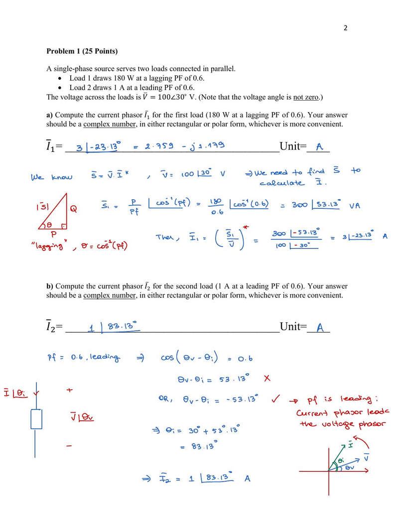

官方答案 · sp24_mt1_sol.pdf · PDF 第 2 页

#### 三个简答练习

以下为本次自拟练习，不是历年卷原小问，也不用于判断你已掌握。

1. 为何滞后负载的 Q 为正？
2. 画出两个并联负载的电流方向和电压极性。
3. 总 PF 能否取各负载 PF 的算术平均？

**展开参考答案**

1. 以吸收功率为正的被动约定下，电流落后电压使 VI* 的角度为正，因此虚部 Q 为正。
2. 两支路共用同一电压；每个电流流入该负载标为正的电压端。
3. 不能。先加 P、Q 得总复功率，再算 P/√(P²+Q²)，由总 Q 判超前或滞后。

### B 平衡三相负载的线量 相量与总功率

**8 份试卷出现，共 8 个题组。** 每卷 Problem 2 的平衡三相题；Y 与 Δ 连接、每相等效、功率反推和同阻抗换接都归入这一类。

#### 出现次数的逐项证据

| 试卷 | 原题号 | PDF 页码 | 题面证据与归类理由 |
| --- | --- | --- | --- |
| Fall 2019 PDF | 2(a,b,e) | 4, 5 | 4160 V、1200 kVA，画三相与每相等效图并反求 Δ 阻抗。 |
| Spring 2021 PDF | 2(a,b) | 2 | 4160 V，两个 Y 负载与一个 Δ 负载，求各负载复功率和总线电流。 |
| Fall 2021 PDF | 2(a) | 4 | 208 V，Y 负载给线电流，Δ 负载给相电流，求总线电流。 |
| Spring 2022 PDF | 2(a,b) | 4, 5 | 480 V、300 kVA、Δ 阻抗 50+j50 Ω，画每相等效图并求各线电流。 |
| Spring 2023 PDF | 2(a–c) | 4, 5 | 578 V，电容加入后线电流 30 A→45 A，求 Y/Δ 每相量并反推原负载复功率。 |
| Fall 2023 PDF | 2(a,b) | 5, 6 | 11 kV，300 kW Y 负载与 3 A/相的纯容性 Δ 负载，求 P、Q 和线电流。 |
| Spring 2024 PDF | 2(a–d) | 4, 5 | 208 V，混合 Y/Δ 负载，求 P、线电流、Δ 阻抗；保持每相阻抗把 Δ 改 Y。 |
| Fall 2024 PDF | 2(a) | 4 | 208 V、1500 W，新增 Y 纯无功负载后线电流 5 A→7 A，反求每相阻抗。 |

#### 代表题整理

**选题：Spring 2022，Problem 2(a,b)，PDF 第 4, 5 页。**

Y 源线电压 480 V。负载 1 为 Y 接，三相 300 kVA、PF=0.6 滞后；负载 2 为 Δ 接，每相阻抗 50+j50 Ω。画每相等效图，标源电压、负载 1 每相功率、负载 2 等效阻抗，再以极坐标给出两个负载线电流和总线电流。

**展开完整英文原题与原图**

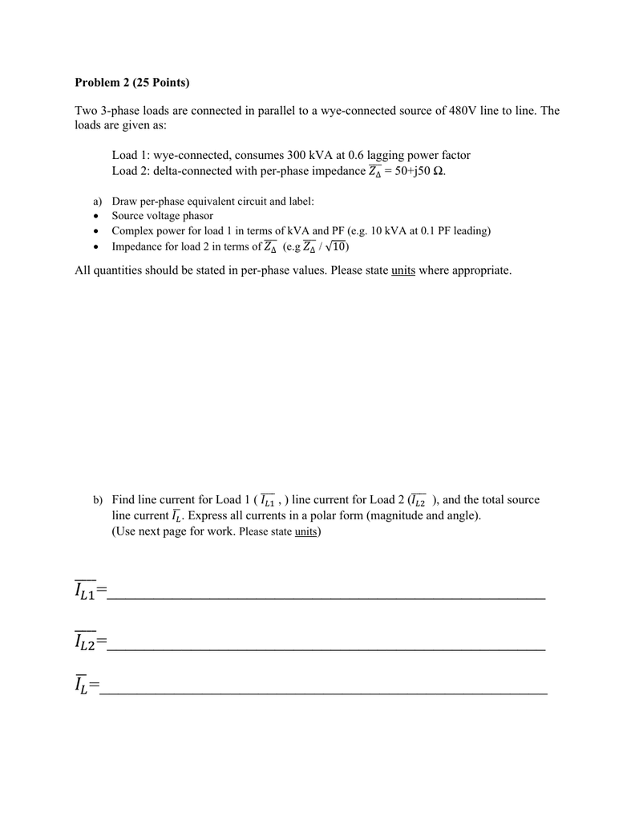

[figure not shown]

#### 建模与解题抓手

[figure not shown]

图为本次绘制的分析模型；J 为气隙局部示意。以本段条件与符号为准，具体原题拓扑和极性仍可在上方原页核对。

平衡系统按同一相建立等效电路，先统一每相量，再求相量电流。

$$V_{\phi,Y}=\frac{V_L}{\sqrt3},\quad I_{\phi,Y}=I_L,\quad V_{\phi,\Delta}=V_L,\quad |I_{L,\Delta}|=\sqrt3|I_{\phi,\Delta}|,\quad Z_Y=\frac{Z_\Delta}{3}.$$

$$\bar S_{3\phi}=3\bar V_\phi\bar I_\phi^*,\qquad |\bar S_{3\phi}|=\sqrt3V_L|I_L|.$$

最后一式只给幅值，不给相角。求电流相角必须说明参考相电压和相序。sp24 2(d) 保持同一物理阻抗改接 Y，是改变负载；并非为了等效而把阻抗除以 3。

### 详细解答 · 三相每相模型与线电流

**1. 选 a 相相电压为参考**

$$\bar V_{aN}=\frac{V_L}{\sqrt3}\angle0^\circ=\frac{480}{\sqrt3}\angle0^\circ=277.128\angle0^\circ\ \mathrm{V}.$$

两负载都换到同一个 Y 型每相电路；Y 接的相电流就是线电流。

**2. 负载 1：三相总功率先除以 3**

$$|\bar S_{1\phi}|=\frac{300}{3}=100\ \mathrm{kVA},$$
$$\bar S_{1\phi}=100(0.6+j0.8)=(60+j80)\ \mathrm{kVA}.$$
$$\bar I_1=\left(\frac{\bar S_{1\phi}}{\bar V_{aN}}\right)^*=\frac{60000-j80000}{277.128}=(216.506-j288.675)\ \mathrm{A}.$$
$$\boxed{\bar I_1=360.844\angle(-53.130^\circ)\ \mathrm{A}.}$$

**3. 负载 2：把 Δ 阻抗等效成 Y 阻抗**

$$Z_{2Y}=\frac{Z_{2\Delta}}{3}=\frac{50+j50}{3}=(16.6667+j16.6667)\ \Omega,$$
$$\bar I_2=\frac{\bar V_{aN}}{Z_{2Y}}=\frac{277.128}{16.6667+j16.6667}=(8.31384-j8.31384)\ \mathrm{A}.$$
$$\boxed{\bar I_2=11.7576\angle(-45.000^\circ)\ \mathrm{A}.}$$

这是等效 Y 电路中的线电流，不再乘 $\sqrt3$。

**4. 在直角坐标下相加，再转为极坐标**

$$\bar I_L=\bar I_1+\bar I_2=(224.820-j296.989)\ \mathrm{A},$$
$$\boxed{\bar I_L=372.487\angle(-52.874^\circ)\ \mathrm{A}.}$$

**核对：**官方使用较粗的中间舍入，给出约 $373\angle(-53^\circ)\ \mathrm{A}$。不要直接相加两个电流幅值。

**核对官方答案原页（直接在本页查看）**

以下是官方 solution 的 PDF 第 4 页。打开完整官方 PDF

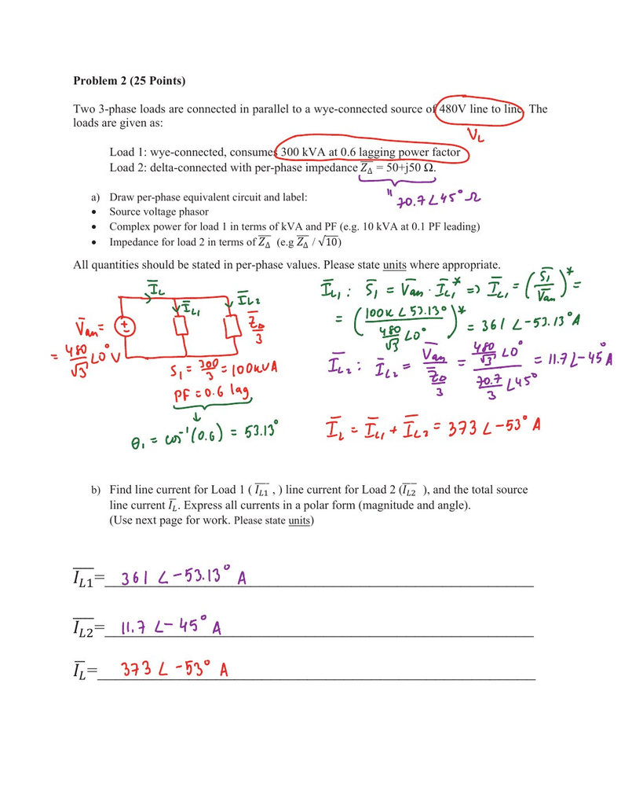

官方答案 · sp22_mt1_sol.pdf · PDF 第 4 页

#### 三个简答练习

以下为本次自拟练习，不是历年卷原小问，也不用于判断你已掌握。

1. Δ 转 Y 为何除以 3？
2. 300 kVA 三相总量进入每相图是多少？
3. 能否给 Δ 负载直接使用 VL/√3？

**展开参考答案**

1. 这是平衡端口等效转换，使端口线电压和线电流不变；不是物理换接时自动改变元件阻抗。
2. 100 kVA/相，PF 保持 0.6 滞后。
3. 原 Δ 每相承受 VL；只有将其转换为等效 Y 后，每相才使用 VL/√3。

### C 单线圈磁路的磁阻 磁通 磁链与电感

**8 份试卷出现，共 8 个题组。** 每卷 Problem 3。求磁阻、磁通、磁链、电感或由磁链求电压均归于单线圈磁路主干；未把多线圈参数题算入。

#### 出现次数的逐项证据

| 试卷 | 原题号 | PDF 页码 | 题面证据与归类理由 |
| --- | --- | --- | --- |
| Fall 2019 PDF | 3(a–c) | 6, 7 | 300 匝、μr=2000、2 mm 气隙，画磁路、求总磁通和 L。 |
| Spring 2021 PDF | 3 | 3 | 250 匝、μr=2500、两处图示气隙 g=10 mm，求 L。 |
| Fall 2021 PDF | 3(a–c) | 5, 6 | 无限磁导率主体、两个有限磁导率插块、三处图示气隙，求磁路、磁通及 v(i)。 |
| Spring 2022 PDF | 3(a,b) | 7, 8 | μr=1000、中心气隙、考虑 fringing，画磁路并求 L。 |
| Spring 2023 PDF | 3(a–c) | 6, 7 | 450 匝、两个 μr=2450 插块与中心气隙，求磁路、磁链及 v(t)。 |
| Fall 2023 PDF | 3(a) | 7 | μ=∞、12 匝、三条支路给磁阻，画极性正确的磁路并求 L。 |
| Spring 2024 PDF | 3(a) | 6 | μr=11、100 匝、中心气隙 1 cm，画三支路磁路并求 L。 |
| Fall 2024 PDF | 3(a–c) | 6, 7 | 环形铁芯 μr=1500、内半径 10 cm、截面直径 2 cm、10° 切口，求磁阻、磁通和 L。 |

#### 代表题整理

**选题：Fall 2024，Problem 3(a–c)，PDF 第 6, 7 页。**

环形铁芯相对磁导率 1500，内半径 R=10 cm，圆形截面直径 D=2 cm，切口角 θ=10°，100 匝。忽略边缘效应。求铁芯与气隙磁阻、以未知电流 i 表示的总磁通和电感。原题提示弧长 l=rθ。

**展开完整英文原题与原图**

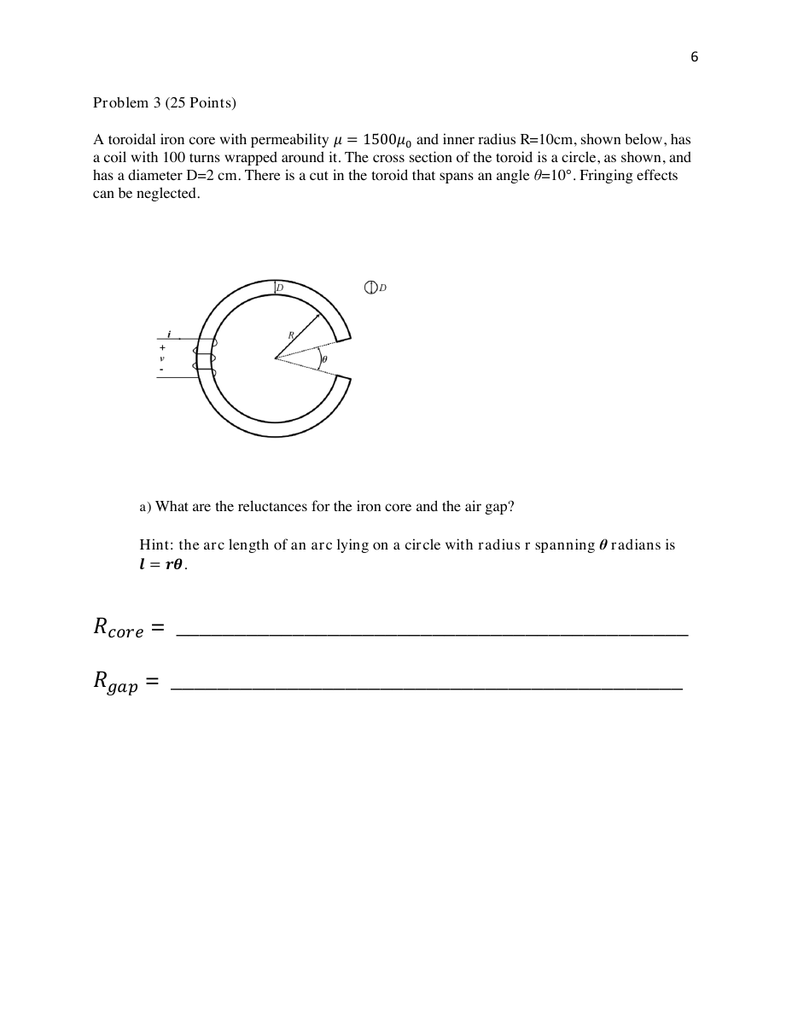

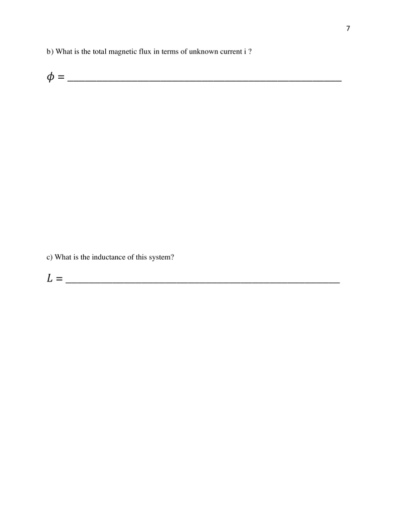

#### 建模与解题抓手

[figure not shown]

图为本次绘制的分析模型；J 为气隙局部示意。以本段条件与符号为准，具体原题拓扑和极性仍可在上方原页核对。

先沿中心线取磁路长度，截面积垂直于磁通方向。图示气隙有几处就计几处；不能仅从题干出现一个 g 推断只有一个气隙。

$$\mathcal R_k=\frac{l_k}{\mu_k A_k},\qquad Ni=\mathcal R_{\mathrm{eq}}\phi,\qquad \lambda=N\phi=Li.$$

代表题为单回路：$r_{\mathrm{mean}}=R+D/2$，$A=\pi(D/2)^2$，$l_g=r_{\mathrm{mean}}\theta$，$l_c=r_{\mathrm{mean}}(2\pi-\theta)$，角度以弧度代入。随后 $L=N^2/(\mathcal R_c+\mathcal R_g)$。分支磁路须先列磁通守恒与 MMF 方程；并联磁阻不能直接串加。

### 详细解答 · 环形磁路的磁阻、磁通与电感

**1. 求平均半径与圆形截面积**

$$r=R+\frac D2=0.10+\frac{0.02}{2}=0.11\ \mathrm{m},$$
$$A=\pi\left(\frac D2\right)^2=\pi(0.01)^2=3.14159\times10^{-4}\ \mathrm{m^2}.$$

**2. 把气隙角度换成弧度，分别求弧长**

$$\theta=10^\circ\times\frac{\pi}{180^\circ}=\frac{\pi}{18},$$
$$\ell_g=r\theta=0.0191986\ \mathrm{m},\qquad \ell_c=r(2\pi-\theta)=0.671952\ \mathrm{m}.$$

气隙采用题目给出的弧长近似；铁芯长度扣除切口。

**3. 铁芯与气隙的磁阻串联**

$$\mu_0=4\pi\times10^{-7}\ \mathrm{H/m},\qquad \mu_c=1500\mu_0,$$
$$\mathcal R_c=\frac{\ell_c}{1500\mu_0A}=1.13472\times10^6\ \mathrm{At/Wb},$$
$$\mathcal R_g=\frac{\ell_g}{\mu_0A}=4.86307\times10^7\ \mathrm{At/Wb},$$
$$\mathcal R_{\mathrm{tot}}=\mathcal R_c+\mathcal R_g=4.97654\times10^7\ \mathrm{At/Wb}.$$

**4. 从磁动势求磁通，再求磁链与电感**

$$Ni=\mathcal R_{\mathrm{tot}}\Phi,\qquad \lambda=N\Phi=Li,$$
$$\boxed{\Phi(i)=\frac{100i}{4.97654\times10^7}=(2.00943\times10^{-6}\ \mathrm{Wb/A})\,i,}$$
$$\boxed{L=\frac{N^2}{\mathcal R_{\mathrm{tot}}}=\frac{100^2}{4.97654\times10^7}=0.200943\ \mathrm{mH}.}$$

题目未给定电流，磁通应保留为 $i$ 的函数。官方中间舍入得到约 $2.008\times10^{-4}\ \mathrm H$。**易错点：**磁路用平均半径；$\ell=r\theta$ 中的角度必须是弧度。

**核对官方答案原页（直接在本页查看）**

以下是官方 solution 的 PDF 第 6、7 页。打开完整官方 PDF

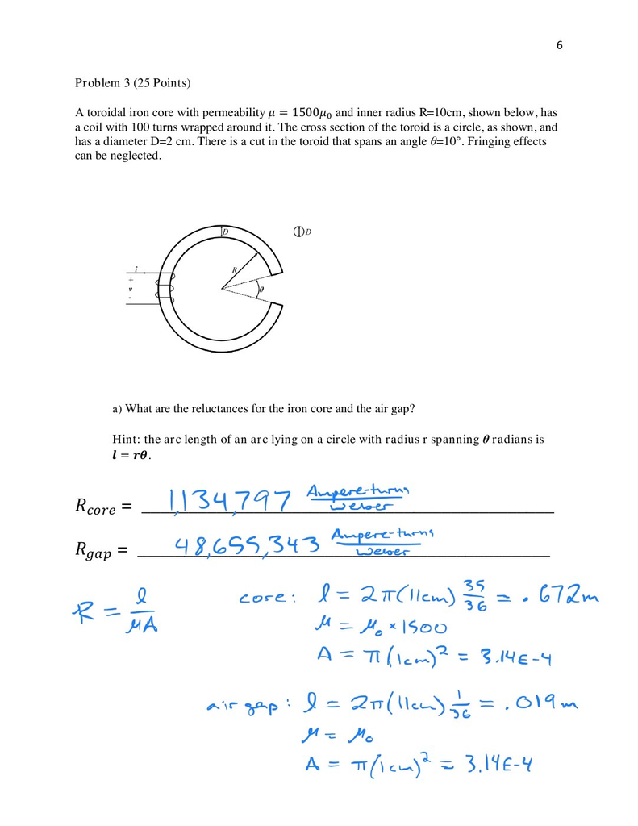

官方答案 · fa24_mt1_sol.pdf · PDF 第 6 页

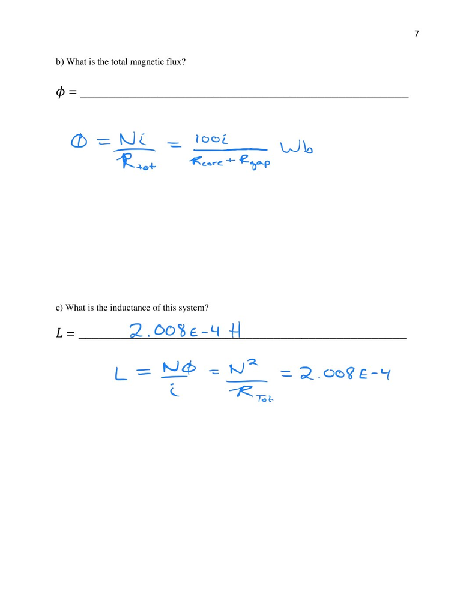

官方答案 · fa24_mt1_sol.pdf · PDF 第 7 页

#### 三个简答练习

以下为本次自拟练习，不是历年卷原小问，也不用于判断你已掌握。

1. 题目给内半径 R，磁路长度能直接用 2πR 吗？
2. 磁通 φ 与磁链 λ 有什么区别？
3. 无限磁导率铁芯还需要保留磁阻吗？

**展开参考答案**

1. 不能；本题中心线半径为 R+D/2，并须分别扣出气隙与铁芯弧段。
2. φ 为单匝穿链磁通，单位 Wb；均匀穿链时 λ=Nφ，单位 Wb·turn。
3. 该理想铁芯段的磁阻取零，但有限磁导率插块和气隙仍须保留。

### D 求自感 互感及耦合线圈的等效电感

**7 份试卷出现，共 7 个题组。** 明确要求求 L1、L2、M 或从串并联测量反推 L、M。题干仅给出这些参数的响应题不计入。

#### 出现次数的逐项证据

| 试卷 | 原题号 | PDF 页码 | 题面证据与归类理由 |
| --- | --- | --- | --- |
| Fall 2019 PDF | 4(a,b) | 8 | 先标 dot terminals，再求 L1、L2、M。 |
| Spring 2021 PDF | 4(a,c) | 4, 5 | 由 Ra、Rb 求 M；两线圈串联后求总电感。 |
| Fall 2021 PDF | 4(b) | 8 | 两处气隙磁阻，求 L1、L2、M。 |
| Spring 2022 PDF | 4(a) | 9, 10 | 三处气隙磁阻，求 L1、L2、M。 |
| Spring 2023 PDF | 4(b) | 8, 9 | 三处气隙磁阻，求 L1、L2、M。 |
| Fall 2023 PDF | 4(b) | 10 | 从串联 8 mH、并联 5 mH 反推相同线圈的 L、M。 |
| Spring 2024 PDF | 4(a) | 8 | 10 与 20 匝、两处气隙 5 和 15 At/Wb，求 L1、L2、M。 |

#### 代表题整理

**选题：Spring 2024，Problem 4(a)，PDF 第 8 页。**

两线圈分别 10 匝与 20 匝。铁芯磁阻可忽略；两处气隙磁阻为 R1=5、R2=15 At/Wb。求各线圈自感 L1、L2 与互感 M，题目明确 M 应取正。

**展开完整英文原题与原图**

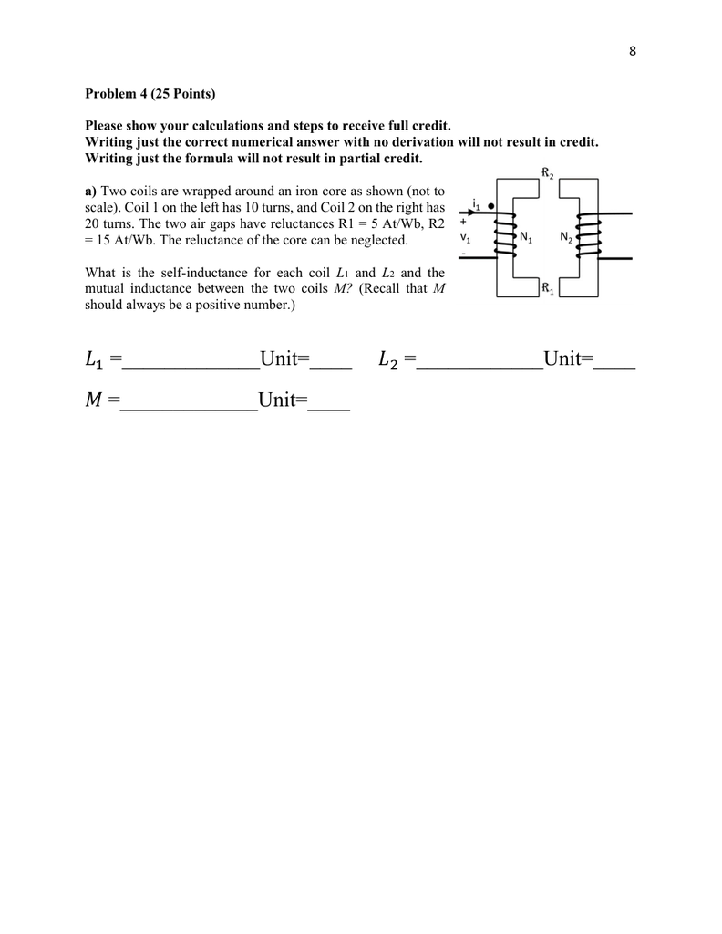

#### 建模与解题抓手

[figure not shown]

图为本次绘制的分析模型；J 为气隙局部示意。以本段条件与符号为准，具体原题拓扑和极性仍可在上方原页核对。

单独激励一个绕组，分别求本绕组穿链磁通和另一绕组穿链磁通。

$$L_1=\frac{N_1\phi_{11}}{i_1},\qquad L_2=\frac{N_2\phi_{22}}{i_2},\qquad M=\left|\frac{N_2\phi_{21}}{i_1}\right|.$$

代表题为共用同一磁通的单回路，可用 $L_1=N_1^2/\mathcal R_{\mathrm{eq}}$、$L_2=N_2^2/\mathcal R_{\mathrm{eq}}$、$M=N_1N_2/\mathcal R_{\mathrm{eq}}$，其中 $\mathcal R_{\mathrm{eq}}=R_1+R_2$。这组简式不能直接套到有漏磁支路的 fa21、sp21、sp22、sp23。fa23 的串并联测量须按实际点端列式；本卷文字规定串联为异名端相接、并联为同名端相接，但串联图画成了同为非点端的两端相接。若按文字，两个相同线圈应同时满足 $L_s=2(L+M)$、$L_p=(L+M)/2$，故 $L_s=4L_p$。题给 8 mH 与 5 mH 不满足这一关系。官方 solution 按图采用串联相消、并联相助，得到 L=7 mH、M=3 mH；其采用的串联连接与题干文字不同。本册保留并计一次，标明文字与图示冲突，练习时需先声明按图还是按文字。

### 详细解答 · 共同磁通回路的自感与互感

**1. 根据拓扑求总磁阻**

两个气隙在同一条闭合磁通回路中，铁芯磁阻忽略：

$$\mathcal R_{\mathrm{eq}}=\mathcal R_1+\mathcal R_2=5+15=20\ \mathrm{At/Wb}.$$

**2. 仅激励线圈 1，求其自感**

令 $i_2=0$，则

$$\Phi=\frac{N_1i_1}{\mathcal R_{\mathrm{eq}}},\qquad \lambda_1=N_1\Phi,$$
$$\boxed{L_1=\frac{\lambda_1}{i_1}=\frac{N_1^2}{\mathcal R_{\mathrm{eq}}}=\frac{10^2}{20}=5\ \mathrm H.}$$

**3. 仅激励线圈 2，求其自感**

$$\boxed{L_2=\frac{N_2^2}{\mathcal R_{\mathrm{eq}}}=\frac{20^2}{20}=20\ \mathrm H.}$$

**4. 求另一线圈由共同磁通产生的磁链**

$$|\lambda_{21}|=N_2\Phi=\frac{N_1N_2i_1}{\mathcal R_{\mathrm{eq}}},$$
$$\boxed{M=\frac{|\lambda_{21}|}{|i_1|}=\frac{N_1N_2}{\mathcal R_{\mathrm{eq}}}=\frac{10\times20}{20}=10\ \mathrm H.}$$

**核对：**$M=\sqrt{L_1L_2}=10\ \mathrm H$，符合完全耦合模型。题目要求互感幅值取正；方程中互感项的正负仍由点端与参考方向决定。

**核对官方答案原页（直接在本页查看）**

以下是官方 solution 的 PDF 第 8 页。打开完整官方 PDF

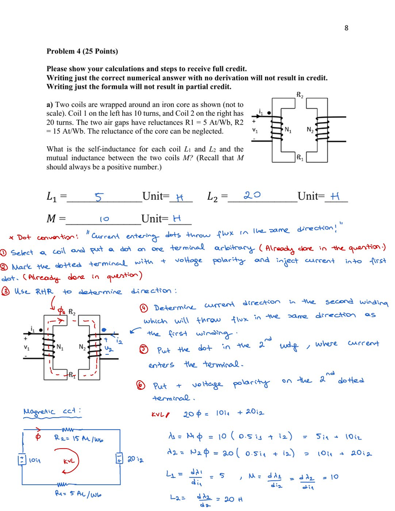

官方答案 · sp24_mt1_sol.pdf · PDF 第 8 页

#### 三个简答练习

以下为本次自拟练习，不是历年卷原小问，也不用于判断你已掌握。

1. M 是正数，是否说明互感项总是正号？
2. 两绕组是否总满足 M=√(L1L2)？
3. 如何分别测定或计算 L1 和 M？

**展开参考答案**

1. 不是。M 是互感幅值，方程中的正负号由点端、电流参考方向及电压极性决定。
2. 只有完全耦合 k=1 才满足；有漏磁通常 k<1。
3. 令 i2=0，激励 i1；本线圈磁链除 i1 得 L1，另一线圈磁链除 i1 的幅值得 M。

### E 电容补偿及补偿前后功率因数和电流

**7 份试卷出现，共 9 个题组。** 明确加入电容并要求补偿容量、目标 PF、补偿后电流或由电容引起的电流变化反推负载。同卷同 Problem 内多个目标 PF 只记一题组。

#### 出现次数的逐项证据

| 试卷 | 原题号 | PDF 页码 | 题面证据与归类理由 |
| --- | --- | --- | --- |
| Fall 2019 PDF | 2(d) | 5 | 补偿到 unity PF，求三相 kVAR 并解释 Y/Δ 接法。 |
| Fall 2021 PDF | 2(b) | 4 | 补偿到 unity PF，求每相容性 VAR 并说明理由。 |
| Spring 2022 PDF | 2(c) | 6 | Δ 电容补偿到 unity PF，求新线电流相量。 |
| Spring 2023 PDF | 1(c) | 3 | 单相补偿到 0.975 lagging，求容性阻抗。 |
| Spring 2023 PDF | 2(b,c) | 4, 5 | 加入 30 kVAR Δ 电容，线电流反而增大，用前后数据求原负载功率。 |
| Fall 2023 PDF | 1(c) | 4 | 单相补偿到 unity PF，求电容电抗。 |
| Fall 2023 PDF | 2(c) | 6 | 三相补偿到 unity PF，求新线电流幅值。 |
| Spring 2024 PDF | 1(c,d) | 3 | 求补偿到 unity 与 0.8 leading 所需 VAR，并解释 leading。 |
| Fall 2024 PDF | 2(b) | 5 | Δ 电容使线电流 7 A→4.75 A，求每相电容 F。 |

#### 代表题整理

**选题：Spring 2023，Problem 1(c)，PDF 第 2, 3 页。**

2∠0° kV、60 Hz 电源给两个并联负载供电。总电流 100 A 且滞后，总有功 150 kW；负载 1 消耗 80 kVA、PF=0.95 滞后。加入并联电容使整体 PF=0.975 滞后，求容性负载阻抗。

**展开完整英文原题与原图**

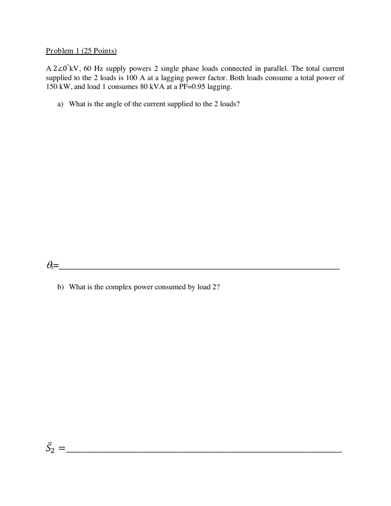

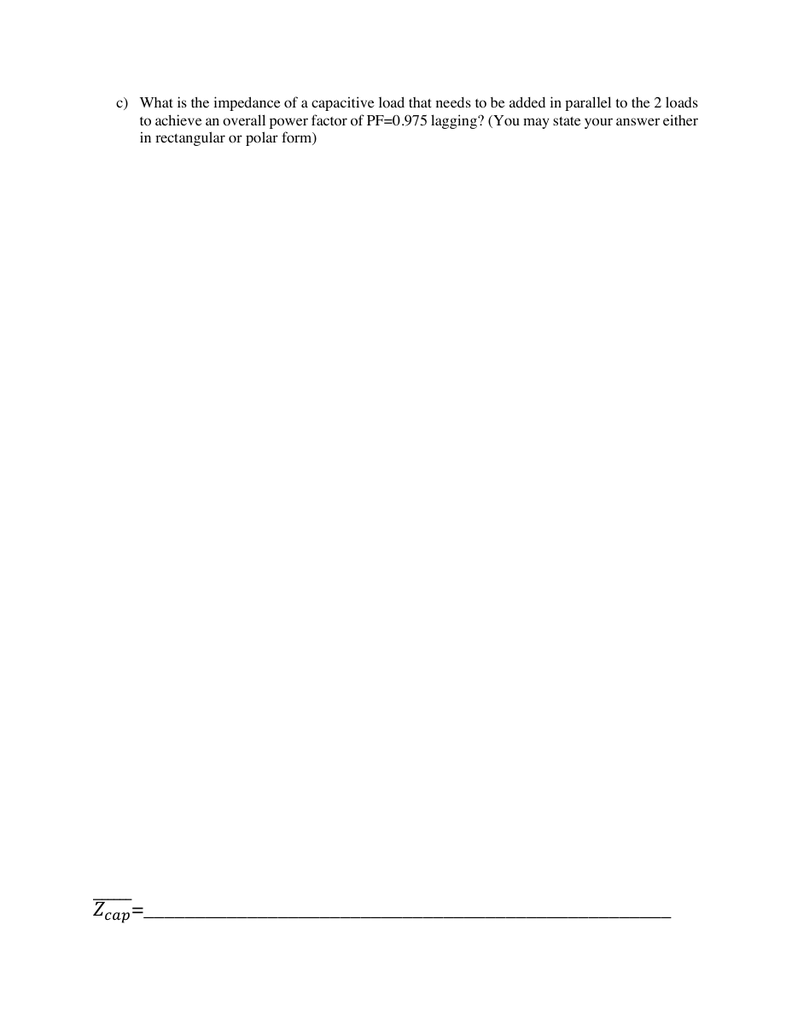

#### 建模与解题抓手

[figure not shown]

图为本次绘制的分析模型；J 为气隙局部示意。以本段条件与符号为准，具体原题拓扑和极性仍可在上方原页核对。

补偿改变 Q，理想并联电容不消耗平均有功。目标必须带 leading 或 lagging。

$$Q_{\mathrm{target}}=\begin{cases}+P\tan(\cos^{-1}\mathrm{PF}_{\mathrm{target}}),&\text{lagging}\\-P\tan(\cos^{-1}\mathrm{PF}_{\mathrm{target}}),&\text{leading}\end{cases},\quad Q_C=Q_{\mathrm{target}}-Q_{\mathrm{old}}.$$

$$Z_C=-j\frac{V^2}{|Q_C|},\qquad C_{\mathrm{per\ phase}}=\frac{|Q_{C,3\phi}|}{3\omega V_{\phi,C}^{\,2}}.$$

第二式的三相量与每相电压须对应；Δ 电容用 $V_{\phi,C}=V_L$，Y 电容用 $V_L/\sqrt3$。通常报告容量 $|Q_C|$ 为正，复功率里的电容 Q 为负。sp23 2(c) 专门提醒：加电容不保证线电流减小。

### 详细解答 · 功率因数补偿与电容阻抗

**1. 求补偿前的总无功**

$$|\bar S_0|=V_{\mathrm{rms}}I_{\mathrm{rms}}=2000\times100=200\ \mathrm{kVA},$$
$$Q_0=+\sqrt{|\bar S_0|^2-P^2}=\sqrt{200^2-150^2}=132.288\ \mathrm{kvar}.$$

正号来自题目给定的滞后功率因数。

**2. 保持有功不变，求目标无功**

$$Q_{\mathrm{new}}=P\tan\bigl(\cos^{-1}0.975\bigr)=150\tan\bigl(\cos^{-1}0.975\bigr)=34.1854\ \mathrm{kvar}.$$

目标仍是滞后，所以补偿后无功为正，不应补到零。

**3. 电容提供所需的无功差额**

$$Q_c=Q_{\mathrm{new}}-Q_0=34.1854-132.288=-98.1022\ \mathrm{kvar},$$
$$\bar S_c=-j98102.2\ \mathrm{VA}.$$

**4. 由复功率反求电容阻抗**

$$\bar S_c=\frac{|\bar V|^2}{Z_c^*}\quad\Longrightarrow\quad Z_c=\frac{|\bar V|^2}{\bar S_c^*},$$
$$\boxed{Z_c=\frac{2000^2}{j98102.2}=-j40.7738\ \Omega.}$$

若还要电容量，利用 $\omega=2\pi\times60$：

$$C=\frac{1}{\omega|X_c|}=\frac{1}{2\pi\times60\times40.7738}=65.056\ \mu\mathrm F.$$

**易错点：**使用电压有效值，并把 kvar 换成 var。全系统有功与总电流已足够求补偿量，负载 1 信息用于原题其他小问。

**核对官方答案原页（直接在本页查看）**

以下是官方 solution 的 PDF 第 3 页。打开完整官方 PDF

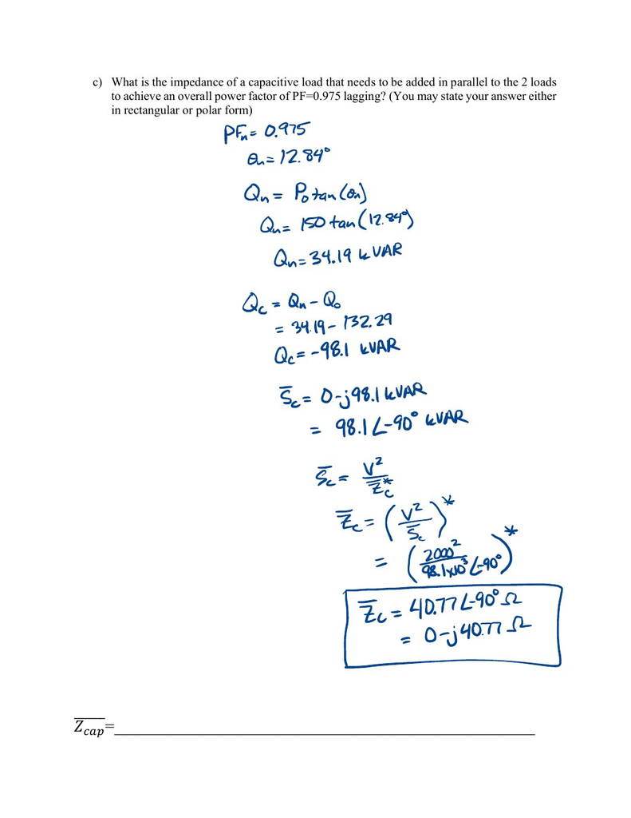

官方答案 · sp23_mt1_sol.pdf · PDF 第 3 页

#### 三个简答练习

以下为本次自拟练习，不是历年卷原小问，也不用于判断你已掌握。

1. 补偿到 unity PF 的目标 Q 是多少？
2. 同一 P 下 0.8 leading 与 0.8 lagging 是否同一补偿量？
3. 画补偿电容应串联还是并联？

**展开参考答案**

1. 为零，因此电容的带符号无功为 −Qold。
2. 不是。目标 Q 大小相同、符号相反，必须按目标 Q 减原 Q。
3. 本组原题要求并联补偿；并联支路共用负载电压，新增电容电流与负载电流按相量相加。

### F 耦合线圈开路电压与短路电流

**6 份试卷出现，共 6 个题组。** 用互感微分方程或相量模型求非理想耦合线圈响应。纯理想匝比小问归 G；本类含输入电流给定及输入电压给定两种激励。

#### 出现次数的逐项证据

| 试卷 | 原题号 | PDF 页码 | 题面证据与归类理由 |
| --- | --- | --- | --- |
| Fall 2019 PDF | 4(c) | 9 | 给 i1=√2·10 cos(377t)，求开路 v2(t)。 |
| Fall 2021 PDF | 4(c) | 9 | 用刚求出的 L1、L2、M，求 1∠0° kV 输入下的实际开路 V2。 |
| Spring 2022 PDF | 4(b) | 11 | 11∠45° kV 输入，求实际开路 V2 的幅值与相位。 |
| Spring 2023 PDF | 4(c) | 10 | 1∠45° kV 输入，求实际开路 V2。 |
| Spring 2024 PDF | 4(b) | 9 | L1=10 H、L2=5 H、M=5 H，次级短路，求 i2(t)。 |
| Fall 2024 PDF | 4(b) | 9 | L1=2 H、L2=250 H、M=5 H，次级开路，求 v2(t)。 |

#### 代表题整理

**选题：Spring 2024，Problem 4(b)，PDF 第 9 页。**

L1=10 H、L2=5 H、M=5 H；次级短路，两个参考电流都流入各自点端，电压上正下负。初级施加 v1(t)=√2 cos(120πt) V，求与原图方向一致的次级短路电流 i2(t)。

**展开完整英文原题与原图**

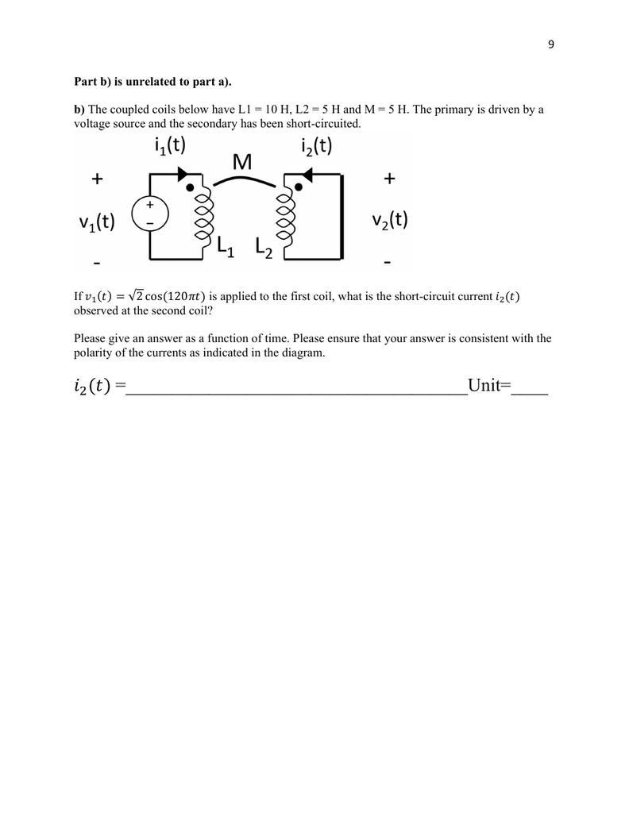

#### 建模与解题抓手

[figure not shown]

图为本次绘制的分析模型；J 为气隙局部示意。以本段条件与符号为准，具体原题拓扑和极性仍可在上方原页核对。

先同时标点端、电流与电压。两个电流均流入点端且电压采用被动极性时，互感项为正。

$$v_1=L_1\frac{di_1}{dt}+M\frac{di_2}{dt},\qquad v_2=M\frac{di_1}{dt}+L_2\frac{di_2}{dt}.$$

开路为 $i_2=0$；若输入电压已知，则 $\bar V_2=(M/L_1)\bar V_1$，但极性不同可能多一个负号。短路为 $v_2=0$，正弦稳态下 $\bar I_2=-(M/L_2)\bar I_1$，且初级有效电感 $L_{\mathrm{in}}=L_1-M^2/L_2$。返回时域时区分有效值与峰值；积分得到的直流常数不属于这里采用的正弦稳态响应。

### 详细解答 · 次级短路电流的时域表达式

**1. 按原图方向写出两个耦合方程**

两电流均流入点端，电压上正下负，因此互感项为正：

$$v_1=10\frac{di_1}{dt}+5\frac{di_2}{dt},\qquad v_2=5\frac{di_1}{dt}+5\frac{di_2}{dt}.$$

**2. 代入次级短路条件**

$$v_2=0\quad\Longrightarrow\quad \frac{di_1}{dt}=-\frac{di_2}{dt},$$
$$v_1=-10\frac{di_2}{dt}+5\frac{di_2}{dt}=-5\frac{di_2}{dt}.$$

**3. 代入驱动电压，然后积分**

$$\frac{di_2}{dt}=-\frac{\sqrt2}{5}\cos(120\pi t),$$
$$i_2(t)=-\frac{\sqrt2}{5\times120\pi}\sin(120\pi t)+C.$$

采用正弦稳态响应，取直流常数 $C=0$。

**4. 改写为余弦形式**

$$-\sin x=\cos\left(x+\frac\pi2\right),$$
$$\boxed{i_2(t)=\frac{\sqrt2}{600\pi}\cos\left(120\pi t+\frac\pi2\right)\ \mathrm A,}$$
$$\boxed{i_2(t)=0.750264\cos\left(120\pi t+\frac\pi2\right)\ \mathrm{mA}.}$$

**幅值核对：**$I_{2,\mathrm{rms}}=1/(600\pi)=0.530516\ \mathrm{mA}$。时域余弦前的系数应为峰值；结果方向与原图箭头一致。

**核对官方答案原页（直接在本页查看）**

以下是官方 solution 的 PDF 第 9 页。打开完整官方 PDF

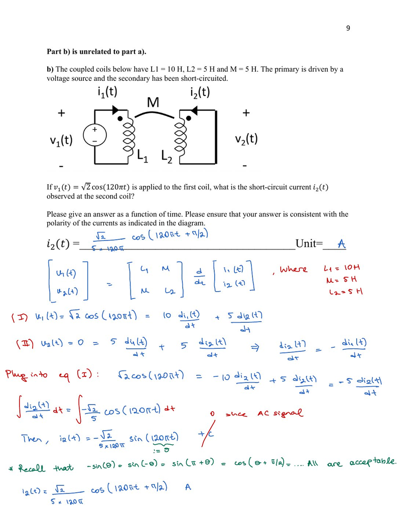

官方答案 · sp24_mt1_sol.pdf · PDF 第 9 页

#### 三个简答练习

以下为本次自拟练习，不是历年卷原小问，也不用于判断你已掌握。

1. 次级开路时，次级电压是否必为零？
2. 次级短路应设置 i2=0 还是 v2=0？
3. 若把 i2 的参考方向反过来，是否能只改最终电流符号？

**展开参考答案**

1. 不是。i2=0，但由初级变化磁通仍可产生互感电压。
2. 设置 v2=0；i2 通常不为零。
3. 必须同步改变方程中与 i2 有关的符号，并核对电压被动极性；代表同一物理解时数值结果可变号。

### G 理想变压器匝比与阻抗折算

**5 份试卷出现，共 5 个题组。** 明确 ideal 假设下求电压、源端所见阻抗或负载功率。输入、输出间有两台变压器也仍是一题组。

#### 出现次数的逐项证据

| 试卷 | 原题号 | PDF 页码 | 题面证据与归类理由 |
| --- | --- | --- | --- |
| Spring 2021 PDF | 4(d) | 5 | 理想匝比 20:10，10 Ω 线路与 2 Ω 负载，求平均负载功率及改进办法。 |
| Fall 2021 PDF | 4(a) | 7 | 先假设理想，10:500 匝比，求开路输出电压与相位。 |
| Spring 2023 PDF | 4(a) | 8 | 先假设理想，400:10 匝比，求 1∠45° kV 的开路输出。 |
| Fall 2023 PDF | 4(a) | 9 | 两台理想变压器和线路阻抗，求源所见 apparent resistance。 |
| Fall 2024 PDF | 4(a.i–iii) | 8 | 240/120 V 理想变压器，1 kW、PF=0.8 滞后，求负载功率、阻抗、折算阻抗。 |

#### 代表题整理

**选题：Fall 2024，Problem 4(a.i–iii)，PDF 第 8 页。**

理想单相变压器额定电压 240/120 V、60 Hz。初级对应 240 V，次级对应 120 V；负载消耗 1 kW，PF=0.8 滞后。求负载复功率、负载阻抗，以及从初级看到的负载阻抗。

**展开完整英文原题与原图**

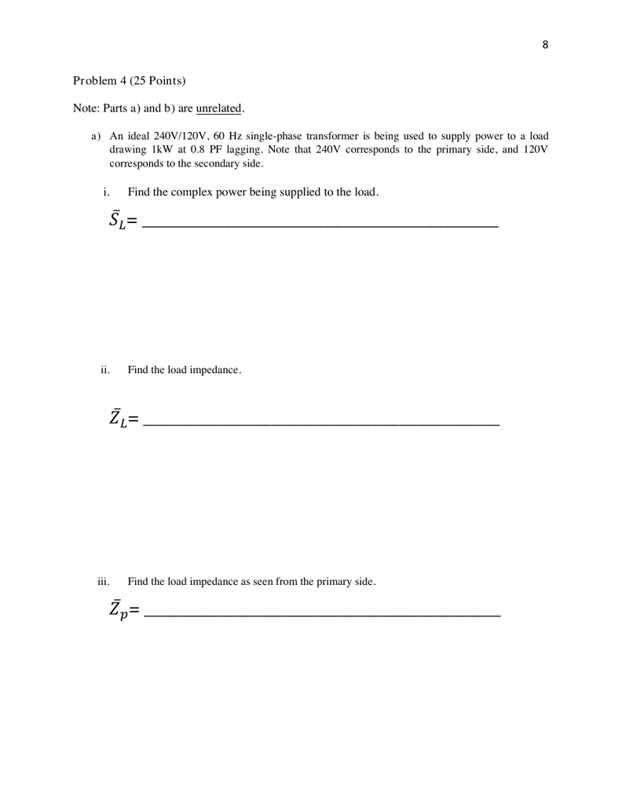

#### 建模与解题抓手

[figure not shown]

图为本次绘制的分析模型；J 为气隙局部示意。以本段条件与符号为准，具体原题拓扑和极性仍可在上方原页核对。

先定义 $a=N_1/N_2$，再确认阻抗折算到哪一侧。

$$|V_2|=\frac{|V_1|}{a},\qquad Z_{L\to1}=a^2Z_L,\qquad Z_L=\frac{|V_2|^2}{\bar S_L^*}.$$

电压符号及相位按点端与测量极性确定；功率复数在无损理想模型下守恒。fa23 的两台变压器应从负载开始逐级折算，在哪一侧串联的线路阻抗，就在哪一侧相加。不要把理想匝比关系直接用来替代 F 类的实际耦合参数。

### 详细解答 · 理想变压器与阻抗折算

**1. 从有功与功率因数求复功率**

$$|\bar S_L|=\frac P{\mathrm{PF}}=\frac{1000}{0.8}=1250\ \mathrm{VA},$$
$$Q_L=P\tan\bigl(\cos^{-1}0.8\bigr)=750\ \mathrm{var},$$
$$\boxed{\bar S_L=(1000+j750)\ \mathrm{VA}=1250\angle36.870^\circ\ \mathrm{VA}.}$$

滞后负载的无功为正。

**2. 使用次级电压求负载阻抗**

$$\bar S_L=\frac{|\bar V_2|^2}{Z_L^*}\quad\Longrightarrow\quad Z_L=\frac{|\bar V_2|^2}{\bar S_L^*},$$
$$\boxed{Z_L=\frac{120^2}{1000-j750}=(9.216+j6.912)\ \Omega=11.52\angle36.870^\circ\ \Omega.}$$

**3. 求变比，再把阻抗折算到初级**

$$a=\frac{N_1}{N_2}=\frac{240}{120}=2,$$
$$Z_L'=a^2Z_L=2^2(9.216+j6.912),$$
$$\boxed{Z_L'=(36.864+j27.648)\ \Omega=46.08\angle36.870^\circ\ \Omega.}$$

**4. 核对功率与电流**

$$\bar I_2=\frac{\bar S_L^*}{\bar V_2}=\frac{1000-j750}{120}=(8.333-j6.25)\ \mathrm A.$$

理想变压器初级电流幅值是次级的 $1/2$，两侧有功均为 1000 W。**易错点：**阻抗乘变比平方；反求阻抗时分母是复功率的共轭。

**核对官方答案原页（直接在本页查看）**

以下是官方 solution 的 PDF 第 8 页。打开完整官方 PDF

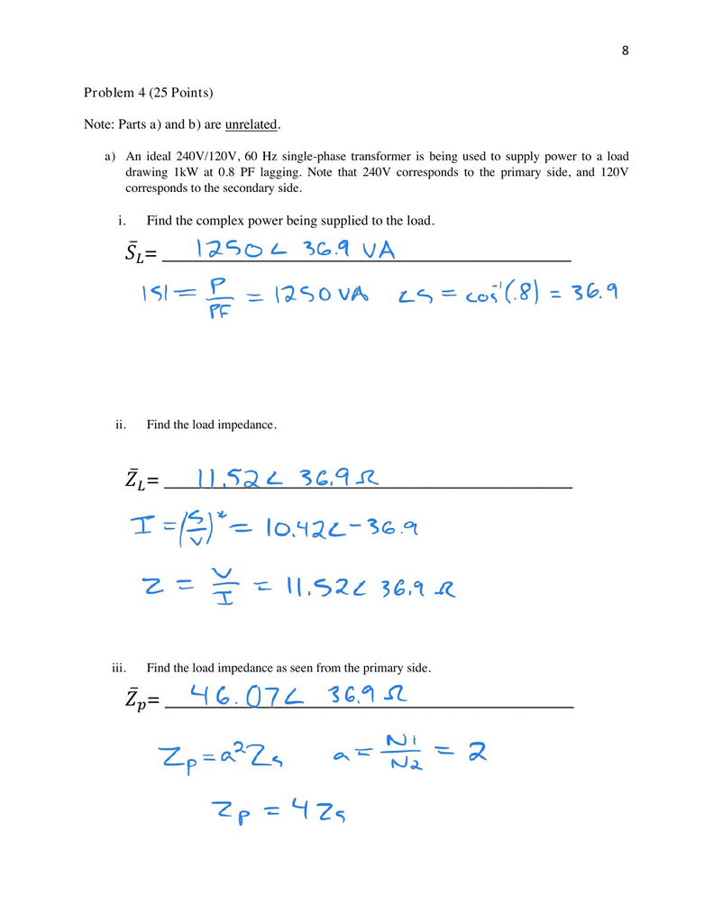

官方答案 · fa24_mt1_sol.pdf · PDF 第 8 页

#### 三个简答练习

以下为本次自拟练习，不是历年卷原小问，也不用于判断你已掌握。

1. 匝比为 2，阻抗折算倍率为多少？
2. 为什么阻抗按匝比平方而非一次方变化？
3. 画折算图时线路电阻如何处理？

**展开参考答案**

1. 由次级折至初级为 4；逆向则除以 4。
2. 电压乘 a，电流除 a，二者之比因此乘 a²。
3. 把负载折到该电阻所在侧后再相加；若继续跨下一台变压器，整个该侧等效阻抗一起折算。

### H 馈线压降 源端功率与负载端功率

**3 份试卷出现，共 3 个题组。** 题干给馈线阻抗，明确要求源端电压、功率或源端 PF。sp21 4(d) 的变压器线路归 G，未重复纳入此类直接馈线题。

#### 出现次数的逐项证据

| 试卷 | 原题号 | PDF 页码 | 题面证据与归类理由 |
| --- | --- | --- | --- |
| Fall 2019 PDF | 1(c,d) | 2, 3 | Zfeeder=1+j2 Ω，求源电压与源端 PF，并与负载端 PF 区分。 |
| Fall 2021 PDF | 1(b–d) | 2, 3 | 馈线 0.1+j0.2 Ω，求源电压、总源功率及源端 PF。 |
| Fall 2024 PDF | 1(a,b) | 2, 3 | 每根供电导线均为 0.1+j0.1 Ω，求源功率与源电压。 |

#### 代表题整理

**选题：Fall 2024，Problem 1(a,b)，PDF 第 2, 3 页。**

三并联负载：100 A、PF=0.8 滞后；8 kW、PF=0.7 滞后；阻抗 5+j2 Ω。负载端电压为 283 sin(377t) V。每根供电导线的阻抗均为 0.1+j0.1 Ω。求源端有功/无功功率及源电压、电流的时域表达式。

**展开完整英文原题与原图**

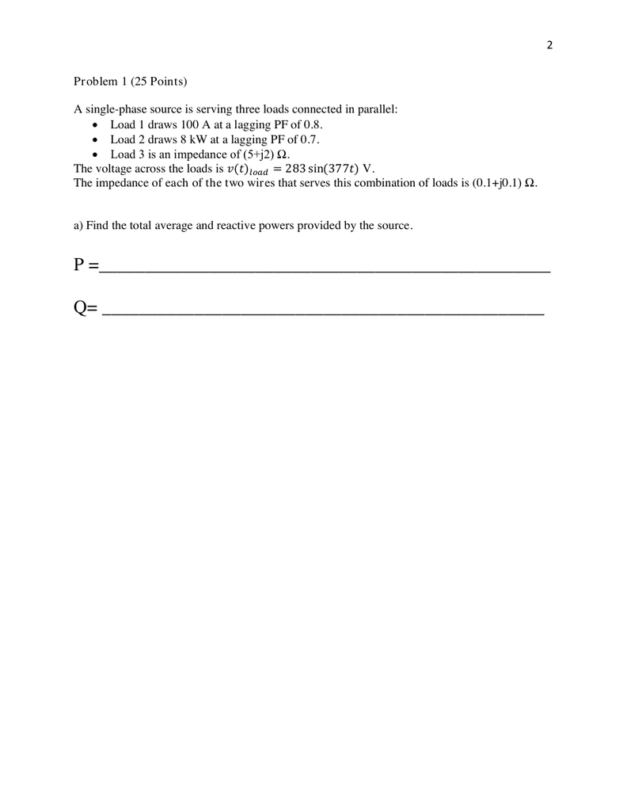

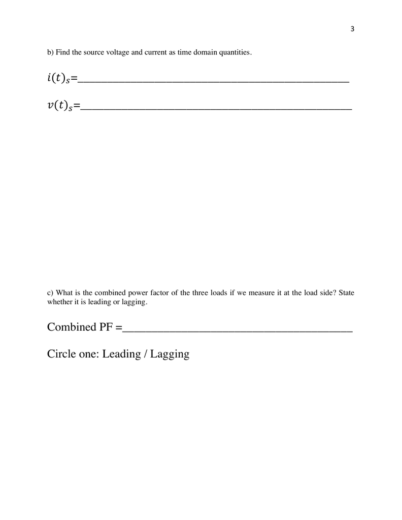

#### 建模与解题抓手

[figure not shown]

图为本次绘制的分析模型；J 为气隙局部示意。以本段条件与符号为准，具体原题拓扑和极性仍可在上方原页核对。

本题有两根导线，因此回路阻抗为每根的两倍。其他卷若已经给总馈线阻抗，不再乘 2。

$$\bar V_s=\bar V_L+Z_{\mathrm{loop}}\bar I,\qquad \bar S_s=\bar S_L+|I|^2Z_{\mathrm{loop}}.$$

必须先求负载总电流，再求压降与线路功率；$|I|^2Z$ 中的电流平方为实数幅值平方。电压波形是 sine（正弦）时，换成 cosine（余弦）参考要减 90°；283 V 是峰值，不是有效值。

### 详细解答 · 导线压降、电源功率与时域量

**1. 先区分峰值、有效值和两根导线**

以负载端的正弦电压为零相位参考，最后也用正弦输出。

$$U=\frac{283}{\sqrt2}=200.111\ \mathrm V,\qquad Z_{\mathrm{wire}}=2(0.1+j0.1)=(0.2+j0.2)\ \Omega.$$

**2. 分别求三支路复功率，再相加**

$$\bar S_1=100U(0.8+j0.6)=(16.0089+j12.0067)\ \mathrm{kVA},$$
$$\bar S_2=8+j8\tan\bigl(\cos^{-1}0.7\bigr)=(8+j8.16163)\ \mathrm{kVA},$$
$$\bar S_3=\frac{U^2}{5-j2}=(6.90422+j2.76169)\ \mathrm{kVA},$$
$$\bar S_{\mathrm{load}}=\bar S_1+\bar S_2+\bar S_3=(30.9131+j22.9300)\ \mathrm{kVA}.$$

**3. 求总电流，再求电源端电压**

$$\bar I=\frac{\bar S_{\mathrm{load}}^*}{U}=(154.480-j114.586)\ \mathrm A=192.338\angle(-36.5664^\circ)\ \mathrm A,$$
$$\bar V_s=U+Z_{\mathrm{wire}}\bar I=(253.924+j7.97869)\ \mathrm V=254.050\angle1.79973^\circ\ \mathrm V.$$

**4. 加上两根导线的功率消耗**

$$\bar S_{\mathrm{wire}}=|\bar I|^2Z_{\mathrm{wire}}=(7.39880+j7.39880)\ \mathrm{kVA},$$
$$\bar S_s=\bar S_{\mathrm{load}}+\bar S_{\mathrm{wire}}=(38.3119+j30.3288)\ \mathrm{kVA},$$
$$\boxed{P_s=38.3119\ \mathrm{kW},\qquad Q_s=30.3288\ \mathrm{kvar}.}$$

**5. 返回时域：有效值乘以 √2**

$$\boxed{i_s(t)=272.007\sin(377t-36.5664^\circ)\ \mathrm A,}$$
$$\boxed{v_s(t)=359.281\sin(377t+1.79973^\circ)\ \mathrm V.}$$

若改用 cos，两个相角均减 $90^\circ$。官方采用约 200 V 与较粗舍入，结果约为 38.3 kW、30.3 kvar；本页按 $283/\sqrt2$ 全程计算。**易错点：**电源端功率必须包含两根导线损耗。

**核对官方答案原页（直接在本页查看）**

以下是官方 solution 的 PDF 第 2、3 页。打开完整官方 PDF

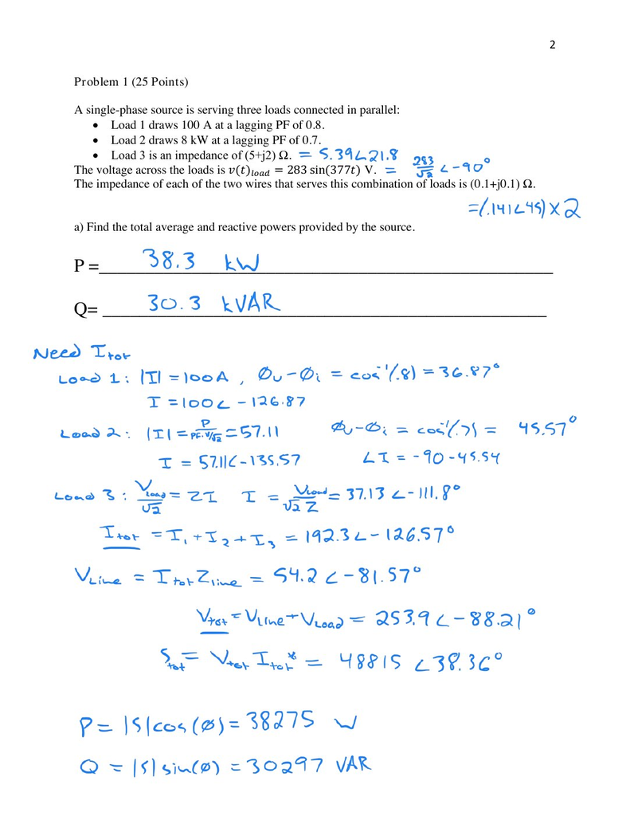

官方答案 · fa24_mt1_sol.pdf · PDF 第 2 页

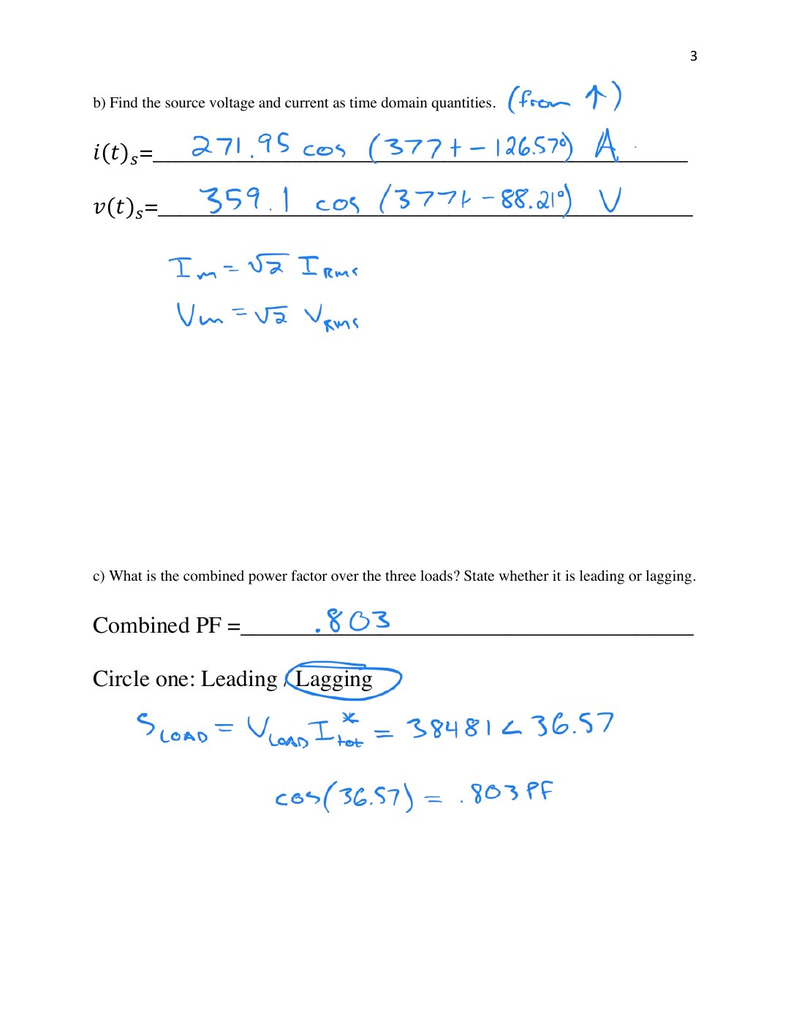

官方答案 · fa24_mt1_sol.pdf · PDF 第 3 页

#### 三个简答练习

以下为本次自拟练习，不是历年卷原小问，也不用于判断你已掌握。

1. 每根导线给 Z 时，回路阻抗为何是 2Z？
2. 线路有电阻时，源端 P 是否等于负载端 P？
3. 源端与负载端 PF 能否共用一个答案？

**展开参考答案**

1. 电流经过去程与回程两根导线，两段阻抗在回路中串联。
2. 不等；源端 P 还须加 |I|²Rloop 的损耗。
3. 不能。分别用各端的总 P、Q 求 PF；线路本身也可能吸收有功与无功。

### I 由磁通密度求电流与饱和上限

**3 份试卷出现，共 3 个题组。** 明确给指定支路的 B，要求电流，或给各腿 B 上限要求最大不饱和电流。

#### 出现次数的逐项证据

| 试卷 | 原题号 | PDF 页码 | 题面证据与归类理由 |
| --- | --- | --- | --- |
| Spring 2022 PDF | 3(c) | 8 | 指定左腿 B=0.5 T，求 i。 |
| Fall 2023 PDF | 3(b) | 8 | 三腿 B 均不能超过 0.1 T，求最大不饱和电流。 |
| Spring 2024 PDF | 3(b) | 7 | 指定中心腿 B=0.5 T，求 i。 |

#### 代表题整理

**选题：Fall 2023，Problem 3(b)，PDF 第 7, 8 页。**

无限磁导率铁芯、12 匝线圈，图中左、中、右支路磁阻分别 6、2、6 At/Wb。三条腿的磁通密度均须不超过 0.1 T。依据图示各腿截面求不饱和最大驱动电流。

**展开完整英文原题与原图**

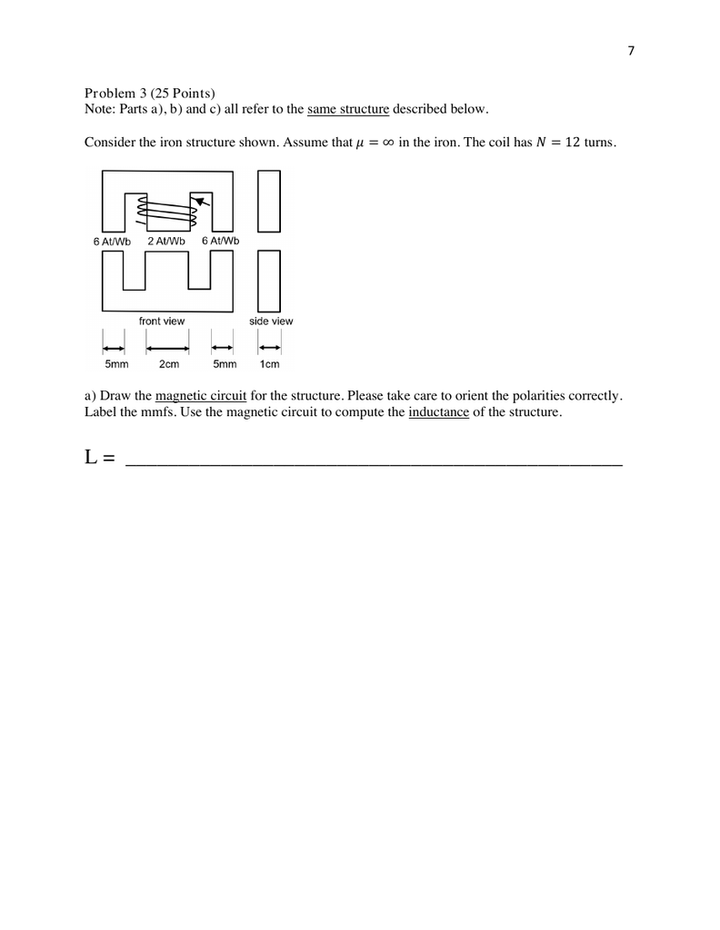

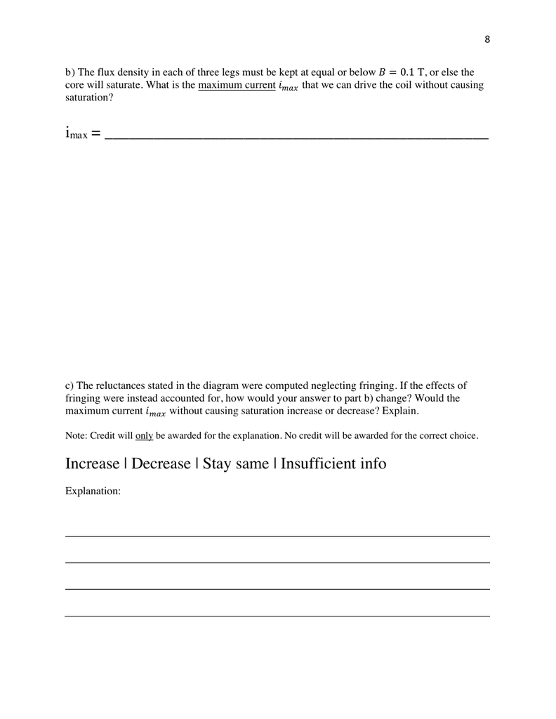

#### 建模与解题抓手

[figure not shown]

图为本次绘制的分析模型；J 为气隙局部示意。以本段条件与符号为准，具体原题拓扑和极性仍可在上方原页核对。

对每条腿分别使用其磁通和截面积，不能把总磁通平均分给各腿。

$$B_k=\frac{\phi_k}{A_k},\qquad \phi_k=\alpha_k i\quad\Longrightarrow\quad i_{\max}=\min_k\frac{B_{\max,k}A_k}{|\alpha_k|}.$$

$\alpha_k$ 是由当前线性磁路求出的该腿磁通对电流的比例。代表题先求分流系数，再逐腿比较上限；最先达到限制的腿决定最终 i。指定中心腿 B 的 sp24 与指定左腿 B 的 sp22 必须对应到各自支路，不能套相同总磁通。

### 详细解答 · 最大不饱和电流

**1. 从原图读出各柱截面积**

$$A_L=A_R=(5\times10^{-3})(10^{-2})=5\times10^{-5}\ \mathrm{m^2},$$
$$A_C=(2\times10^{-2})(10^{-2})=2\times10^{-4}\ \mathrm{m^2}.$$

**2. 求等效磁阻与磁通分流**

$$\mathcal R_{\mathrm{eq}}=2+\frac{6\times6}{6+6}=5\ \mathrm{At/Wb},$$
$$\Phi_C=\frac{Ni}{\mathcal R_{\mathrm{eq}}}=\frac{12i}{5}=2.4i,\qquad \Phi_L=\Phi_R=\frac{\Phi_C}{2}=1.2i.$$

上式中 $i$ 以 A 代入，磁通以 Wb 得出。

**3. 分别计算磁通密度**

$$B_L=B_R=\frac{\Phi_L}{A_L}=\frac{1.2i}{5\times10^{-5}}=24000i,$$
$$B_C=\frac{\Phi_C}{A_C}=\frac{2.4i}{2\times10^{-4}}=12000i.$$

中柱磁通虽更大，但截面积是侧柱的四倍，磁密只有侧柱的一半。

**4. 分别求电流上限，再取最小值**

$$|i|\le\frac{0.1}{24000}=4.16667\ \mu\mathrm A\quad\text{（左右侧柱）},$$
$$|i|\le\frac{0.1}{12000}=8.33333\ \mu\mathrm A\quad\text{（中柱）},$$
$$\boxed{i_{\max}=\min(4.16667,8.33333)=4.16667\ \mu\mathrm A.}$$

此时 $B_L=B_R=0.100\ \mathrm T$，$B_C=0.050\ \mathrm T$。**易错点：**比较的是 $B=\Phi/A$；左右侧柱先到饱和边界，本题单位确实是 μA。

**核对官方答案原页（直接在本页查看）**

以下是官方 solution 的 PDF 第 7、8 页。打开完整官方 PDF

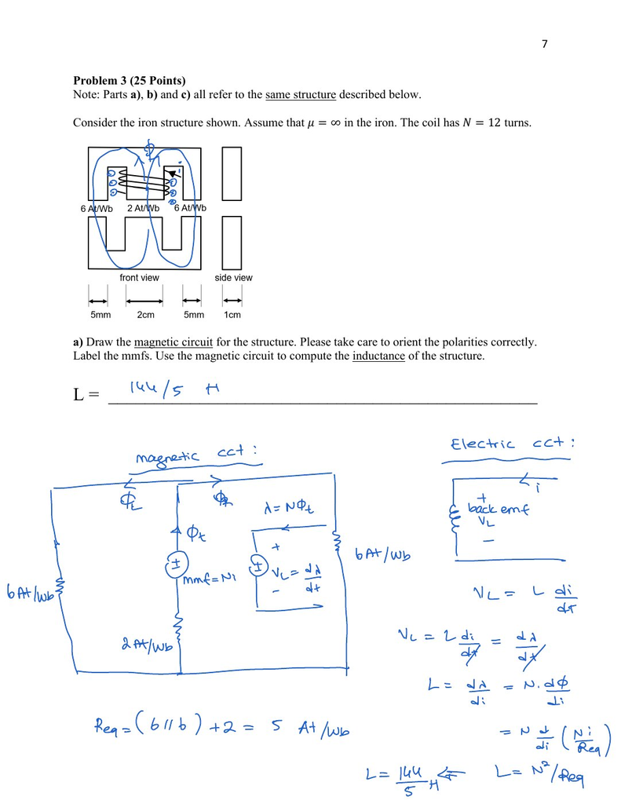

官方答案 · fa23_mt1_sol.pdf · PDF 第 7 页

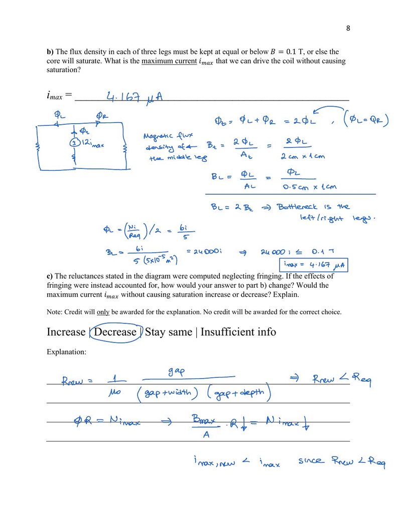

官方答案 · fa23_mt1_sol.pdf · PDF 第 8 页

#### 三个简答练习

以下为本次自拟练习，不是历年卷原小问，也不用于判断你已掌握。

1. 三条腿 B 上限相同，是否说明磁通相同？
2. 最大允许电流应取各腿限制的最大值还是最小值？
3. 画模型时应标哪一个 B？

**展开参考答案**

1. 不一定；φ=BA，各腿截面积可能不同，且磁路分流也不一定均匀。
2. 取最小值，保证每条腿都未超过其上限。
3. 标在题目指定的实际铁芯腿上，再把该腿磁通与截面积对应到方程。

### J 边缘效应对磁阻 电感 互感和电流的影响

**3 份试卷出现，共 3 个题组。** 只统计明确要求考虑 fringing 或解释其后果的小问；题干仅说 neglect fringing 不计出现。

#### 出现次数的逐项证据

| 试卷 | 原题号 | PDF 页码 | 题面证据与归类理由 |
| --- | --- | --- | --- |
| Spring 2021 PDF | 4(b) | 4 | 两处间隙均考虑 fringing，解释 M 增加或减少。 |
| Spring 2022 PDF | 3题干及(a–c) | 7, 8 | 明确 Account for air gap fringing，计算磁路、L 和指定 B 的 i。 |
| Fall 2023 PDF | 3(c) | 8 | 原磁阻忽略 fringing，要求解释计入后不饱和最大电流如何变。 |

#### 代表题整理

**选题：Spring 2021，Problem 4(b)，PDF 第 4 页。**

沿用 Problem 4 的磁结构：无限磁导率超合金、μr=5 的冷却液、N1=20、N2=10，忽略边缘效应时 Ra=200、Rb=800 At/Wb。若计算时考虑边缘效应，互感 M 增加还是减少？必须同时考虑两个间隙并解释。

**展开完整英文原题与原图**

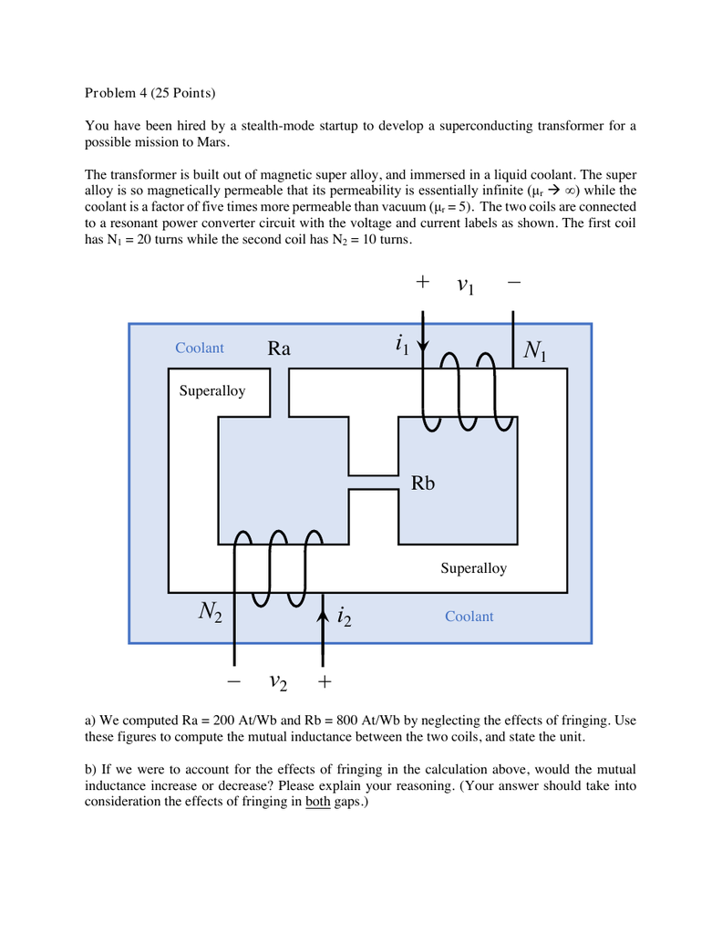

#### 建模与解题抓手

[figure not shown]

图为本次绘制的分析模型；J 为气隙局部示意。以本段条件与符号为准，具体原题拓扑和极性仍可在上方原页核对。

Fringing（边缘效应）使气隙附近磁通扩散，有效通量面积增大。几何近似须与课堂或原题解法一致，不把特定面积修正式当作普适精确公式。

$$\mathcal R_g=\frac{g}{\mu_g A_{g,\mathrm{eff}}},\qquad A_{g,\mathrm{eff}}>A_{\mathrm{core}}.$$

因而在这一集中磁路近似中，同一气隙长度与磁导率下气隙磁阻减小。单回路固定电流时磁通和 L 增大；固定目标磁通时所需电流减小。分支结构中的 M 或饱和电流要把所有受影响支路重算后判断，不能只念“面积增大”便跳到整题结论；代表题明确要求同时分析 Ra 和 Rb。

### 详细解答 · 两处间隙的边缘效应与互感

**1. 先使用本题的分支磁路表达式**

按原图的参考方向，官方磁路给出

$$\Phi_1=N_1i_1\left(\frac1{R_a}+\frac1{R_b}\right)-\frac{N_2i_2}{R_a},$$
$$\Phi_2=\frac{N_2i_2}{R_a}-\frac{N_1i_1}{R_a}.$$

由 $\lambda_1=N_1\Phi_1$、$\lambda_2=N_2\Phi_2$，分别读取自感和互感幅值：

$$L_1=\frac{N_1^2}{R_a\parallel R_b},\qquad L_2=\frac{N_2^2}{R_a},\qquad M=\frac{N_1N_2}{R_a}.$$

交叉项的负号来自参考方向；互感幅值 $M$ 取正。

**2. 计算不考虑边缘效应时的基准值**

$$R_a\parallel R_b=\frac{200\times800}{200+800}=160\ \mathrm{At/Wb},$$
$$L_1=\frac{20^2}{160}=2.5\ \mathrm H,\qquad L_2=\frac{10^2}{200}=0.5\ \mathrm H,$$
$$M_0=\frac{20\times10}{200}=1\ \mathrm H.$$

**3. 两个间隙都考虑边缘效应**

磁通在间隙附近扩展，有效截面积变大，因此在集中磁路近似下

$$\mathcal R_g=\frac{\ell_g}{\mu_gA_{\mathrm{eff}}},\qquad A_{\mathrm{eff}}\uparrow\ \Longrightarrow\ R_a\downarrow,\ R_b\downarrow.$$

**4. 回到本题的互感公式判断趋势**

$$\boxed{M_{\mathrm{new}}=\frac{N_1N_2}{R_{a,\mathrm{new}}}>\frac{N_1N_2}{R_{a,0}}=1\ \mathrm H.}$$

**答案：互感幅值增大。**$R_b$ 的减小也影响 $L_1$，但它不出现在这个拓扑的互感表达式中。题目没有给修正后的有效面积，只能判断趋势，不能确定新数值。不要把两个磁阻直接串加套用共同磁通回路公式。

**核对官方答案原页（直接在本页查看）**

以下是官方 solution 的 PDF 第 9 页。打开完整官方 PDF

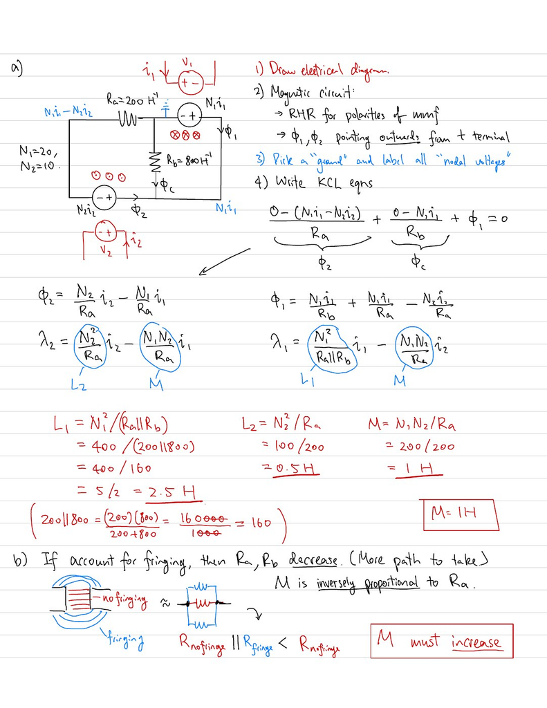

官方答案 · sp21_mt1_sol.pdf · PDF 第 9 页

#### 三个简答练习

以下为本次自拟练习，不是历年卷原小问，也不用于判断你已掌握。

1. 忽略 fringing 与考虑 fringing 的差别应画在哪里？
2. 气隙有效面积增大，集中磁阻如何变化？
3. 有两条磁通路径，能否直接用单回路 L=N²/R 判断全部结果？

**展开参考答案**

1. 画在气隙处：磁通向外扩散、有效截面积改变；铁芯几何截面积不是因此整体变大。
2. 其他量不变时减小，因为 Rg 与有效面积成反比。
3. 不能。先辨认公共磁通与漏磁路径，分别更新受影响磁阻，再求穿链磁通及所问量。

## 低频变体与容易漏掉的要求

| 要求或变体 | 明确出处 | 本册归属 |
| --- | --- | --- |
| 单相题独立由 v(t)、i(t) 求平均功率 | sp21 1(a)，PDF 2 页 | A |
| 明确要求三相图与每相等效图 | fa19 2(a,b)，PDF 4 页；sp22 2(a)，PDF 4 页 | B |
| 保持原每相阻抗，把 Δ 物理改接 Y | sp24 2(d)，PDF 5 页 | B |
| 已知 λ(i) 后求非正弦 v(t) | sp23 3(c)，PDF 7 页；fa21 3(c)，PDF 6 页给 v 与未知 i 的关系 | C |
| 两线圈串联等效电感 | sp21 4(c)，PDF 5 页；fa23 4(b)，PDF 10 页 | D |
| 从串联及并联电感测量反推 L、M | fa23 4(b)，PDF 10 页 | D |
| 次级短路而非开路 | sp24 4(b)，PDF 9 页 | F |
| 同一 Problem 比较理想与实际开路输出 | fa21 4(a,c)，PDF 7、9 页；sp23 4(a,c)，PDF 8、10 页 | G 与 F 分别计 |

这些要求虽有的只出现 1–2 卷，仍可改变整题建模。特别是 point/dot terminals（点端）、方向与极性，是多类题共有的判号依据；不能因为没有单列排名就忽略。

## 八份试卷的全部大题索引

| 试卷 | Problem 1 | Problem 2 | Problem 3 | Problem 4 |
| --- | --- | --- | --- | --- |
| Fall 2019 PDF | PDF 2–3 页 | PDF 4–5 页 | PDF 6–7 页 | PDF 8–9 页 |
| Spring 2021 PDF | PDF 2 页 | PDF 2 页 | PDF 3 页 | PDF 4–5 页 |
| Fall 2021 PDF | PDF 2–3 页 | PDF 4 页 | PDF 5–6 页 | PDF 7–9 页 |
| Spring 2022 PDF | PDF 2–3 页 | PDF 4–6 页 | PDF 7–8 页 | PDF 9–11 页 |
| Spring 2023 PDF | PDF 2–3 页 | PDF 4–5 页 | PDF 6–7 页 | PDF 8–10 页 |
| Fall 2023 PDF | PDF 2–4 页 | PDF 5–6 页 | PDF 7–8 页 | PDF 9–10 页 |
| Spring 2024 PDF | PDF 2–3 页 | PDF 4–5 页 | PDF 6–7 页 | PDF 8–9 页 |
| Fall 2024 PDF | PDF 2–3 页 | PDF 4–5 页 | PDF 6–7 页 | PDF 8–9 页 |

## 来源与统计复核

原题来源为 Canvas 的 本站原卷与官方答案全集，答案来自 本站原卷与官方答案全集。统计以本地空白卷为依据，solution 仅用于答案入口和内容核对；没有把同一试卷的空白版与答案版计两次。

本册的 频率证据 JSON 保存每项来源、题号、页码、归类理由、代表题及源文件 SHA-256；频率表与矩阵由同一份逐项记录计算生成。

本次只建立备考整理，没有推断你的掌握程度，也没有改动任何历史讲义。

## 原卷与官方答案全集

点击直接阅读，无需登录或解压。

| 学期 | 原卷 | 官方答案 |
| --- | --- | --- |
| Fall 2019 | 打开原卷 PDF | 打开官方答案 PDF |
| Spring 2021 | 打开原卷 PDF | 打开官方答案 PDF |
| Fall 2021 | 打开原卷 PDF | 打开官方答案 PDF |
| Spring 2022 | 打开原卷 PDF | 打开官方答案 PDF |
| Spring 2023 | 打开原卷 PDF | 打开官方答案 PDF |
| Fall 2023 | 打开原卷 PDF | 打开官方答案 PDF |
| Spring 2024 | 打开原卷 PDF | 打开官方答案 PDF |
| Fall 2024 | 打开原卷 PDF | 打开官方答案 PDF |